# Table of Contents

## TEXTRANK

### 算法

类似于PageRank的思想，将文本中的 **语法单元** 视作图中的节点，如果两个**语法单元**存在一定语法关系（例如共现），则这两个语法单元在图中就会有一条边相互连接，通过一定的迭代次数，最终不同的节点会有不同的权重，权重高的语法单元可以作为关键词。

参考论文：Rada Mihalcea《TextRank：Bring Order into texts》

节点的权重：不仅依赖于它的入度结点，还依赖于这些入度结点的权重，入度结点越多，入度结点的权重越大，说明这个结点的权重越高；

- 图中任两点 $V_i$ , $V_j$ 之间边的权重为 $w_{ji}$
- 对于一个给定的点 $V_i$
  - In($V_i$) 为 指 向 该 点 的 点 集 合
  - Out($V_i$) 为点$V_i$指出点集合。

TextRank迭代计算公式为：

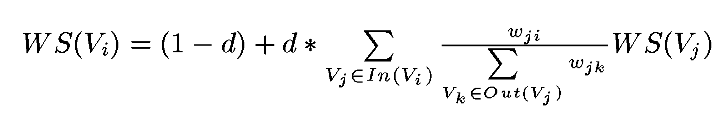

其中, d 为阻尼系数, 取值范围为 0 到 1, 代表从图中某一特定点指向其他任意点的概率, 一般取值为 0.85。

使用TextRank 算法计算图中各点的得分时, 需要给图中的点指定任意的初值, 并递归计算直到收敛, 即图中任意一点的误差率小于给定的极限值时就可以达到收敛, 一般该极限值取 0.0001。算法通用流程：

- 关键短语抽取为例：
1. 预处理，首先进行分词和词性标注，将单个word作为结点添加到图中；
2. 设置语法过滤器，将通过语法过滤器的词汇添加到图中；出现在一个窗口中的词汇之间相互形成一条边；
3. 基于上述公式，迭代直至收敛；一般迭代20-30次，迭代阈值设置为0.0001；
4. 根据顶点的分数降序排列，并输出指定个数的词汇作为可能的关键词；
5. 后处理，如果两个词汇在文本中前后连接，那么就将这两个词汇连接在一起，作为关键短语；

### jieba的实现方式

Jieba中，TextRank是为TextRank算法抽取关键词所定义的类。

- 类在初始化时，默认加载了分词函数和词性标注函数tokenizer = postokenizer = jieba.posseg.dt、
- 停用词表stop_words = self.STOP_WORDS.copy()、
- 词性过滤集合pos_filt = frozenset(('ns', 'n', 'vn', 'v'))，
- 窗口span = 5，
- (("ns", "n", "vn", "v"))表示词性为地名、名词、动名词、动词。
> 1. 首先定义一个无向有权图，然后对句子进行分词；依次遍历分词结果，如果某个词i满足过滤条件（词性在词性过滤集合中，并且词的长度大于等于2，并且词不是停用词）
> 2. 然后将这个词之后窗口长度为5范围内的词j（这些词也需要满足过滤条件），将它们两两（词i和词j）作为key，出现的次数作为value，添加到共现词典中；
> 3. 然后，依次遍历共现词典，将词典中的每个元素，key = （词i，词j），value = 词i和词j出现的次数，将词i和词j作为一条边起始点和终止点，共现的次数作为边的权重，添加到之前定义的无向有权图中。
> 4. 然后对这个无向有权图进行迭代运算textrank算法，最终经过若干次迭代后，算法收敛，每个词都对应一个指标值；
> 5. 如果设置了权重标志位，则根据指标值值对无向有权图中的词进行降序排序，最后输出topK个词作为关键词；

```python
# jieba源码解析
def textrank(self,
             sentence,
             topK=20,
             withWeight=False,
             allowPOS=('ns', 'n', 'vn', 'v'),
             withFlag=False):
    """withWeight：输出各点得分；withFlag：输出词性"""
    self.pos_filt = frozenset(allowPOS)
    # 定义无向有权图
    g = UndirectWeightedGraph()
    # 定义共现词典
    cm = defaultdict(int)
    # 分词
    words = tuple(self.tokenizer.cut(sentence))

    # 依次遍历每个词，cm记录词共现次数
    for i, wp in enumerate(words):
        # 词i 满足过滤条件
        if self.pairfilter(wp):
            # 依次遍历词i 之后窗口范围内的词
            for j in range(i + 1, i + self.span):
                # 词j 不能超出整个句子
                if j >= len(words):
                    break
                # 词j不满足过滤条件，则跳过
                if not self.pairfilter(words[j]):
                    continue
                # 将词i和词j作为key，出现的次数作为value，添加到共现词典中
                if allowPOS and withFlag:
                    cm[(wp, words[j])] += 1
                else:
                    cm[(wp.word, words[j].word)] += 1

    # 依次遍历共现词典的每个元素，将词i，词j作为一条边起始点和终止点，
    # 共现的次数作为边的权重
    for terms, w in list(cm.items()):
        g.addEdge(terms[0], terms[1], w)

    # 运行textrank算法
    nodes_rank = g.rank()

    # 根据指标值进行排序
    if withWeight:
        tags = sorted(list(nodes_rank.items()), key=itemgetter(1), reverse=True)
    # .__getitem__取字典对象成员的值
    else:
        tags = sorted(nodes_rank, key=nodes_rank.__getitem__, reverse=True)

    # 输出topK个词作为关键词
    if topK:
        return tags[:topK]
    else:
        return tags
```

其中，无向有权图的的定义及实现是在UndirectWeightedGraph类中实现的。根据UndirectWeightedGraph类的初始化函数__init__，我们可以发现，所谓的无向有权图就是一个词典，词典的key是后续要添加的词，词典的value则是一个由（起始点，终止点，边的权重）构成的三元组所组成的列表，表示以这个词作为起始点的所有的边。

无向有权图添加边的操作是在addEdge函数中完成的，因为是无向图，所以我们需要依次将start作为起始点，end作为终止点，然后再将start作为终止点，end作为起始点，这两条边的权重是相同的。

```python
def addEdge(self, start, end, weight):
    # use a tuple (start, end, weight) instead of a Edge object
    self.graph[start].append((start, end, weight))
    self.graph[end].append((end, start, weight))
```

#### 权重求解

执行textrank算法迭代是在rank函数中完成的。

> 1. 首先对每个结点赋予相同的权重，以及计算出该结点的所有出度的次数之和；
> 2. 然后迭代若干次，以确保得到稳定的结果；
>    - 在每一次迭代中，依次遍历每个结点；
>    - 对于结点n，首先根据无向有权图得到结点n的所有 入度结点（对于无向有权图，入度结点与出度结点是相同的，都是与结点n相连的结点），
>    - 第一步我们已经计算出这个入度结点的所有出度的次数，而它对于结点n的权值的贡献 = ｛它本身的权值｝ * ｛它与结点n的共现次数｝ / ｛它本身的所有出度的次数｝
>    - 将各个入度结点得到的权值相加，再乘以一定的阻尼系数，即可得到结点n的权值；
> 3. 迭代完成后，对权值进行归一化，并返回各个结点及其对应的权值。

```python
def rank(self):
    ws = defaultdict(float)
    outSum = defaultdict(float)

    # len(self.graph) or 1.0：len(self.graph) 当len(self.graph)>1
    wsdef = 1.0 / (len(self.graph) or 1.0)

    # 统计各个结点的出度的次数之和 out
    for n, out in list(self.graph.items()):
        # 初始化各个结点的权值
        ws[n] = wsdef
        # e[2]：weight，共现次数
        outSum[n] = sum((e[2] for e in out), 0.0)

    # this line for build stable iteration
    sorted_keys = sorted(self.graph.keys())

    # 遍历若干次
    for x in range(10):  # 10 iters
        # 遍历各个结点
        for n in sorted_keys:
            s = 0
            # 遍历结点的入度结点
            for e in self.graph[n]:
                # 将这些入度结点贡献后的权值相加
                # 贡献率 = 入度结点与结点n的共现次数 / 入度结点的所有出度的次数
                s += e[2] / outSum[e[1]] * ws[e[1]]
            # 更新结点n的权值
            ws[n] = (1 - self.d) + self.d * s

    # sys.float_info查看运算精度，min_rank取max，max_rank取min
    (min_rank, max_rank) = (sys.float_info[0], sys.float_info[3])

    # 获取权值的最大值和最小值，itervalues(ws)：value迭代生成器
    for w in itervalues(ws):
        if w < min_rank:
            min_rank = w
        if w > max_rank:
            max_rank = w

    # 对权值进行归一化
    for n, w in list(ws.items()):
        # to unify the weights, don't *100.
        ws[n] = (w - min_rank / 10.0) / (max_rank - min_rank / 10.0)

    return ws
```

### JIEBA使用方法

另外[SnowNLP](https://github.com/isnowfy/snownlp)也有实现

```python
from jieba import analyse

textrank = analyse.textrank

text = "今年全国两会期间，中共中央总书记、国家主席、中央军委主席习近平9天内6次“到团组”，与代表委员面对面商议国是。从全局，到重点领域，再到各地实际，他为“关键之年、攻坚之年”的发展划出路线图，为国家治理这道“方程式”作出解答，成为海内外了解中国、读懂中国的最新“切入点”。"

print("keywords by textrank:")
keywords = textrank(
    text,
    topK=10,
    withWeight=True,
    allowPOS=('ns', 'n', 'vn', 'v'),
    withFlag=False)

words = [(keyword, w) for keyword, w in keywords if w > 0.1]
print(words)
# print(' '.join(words) + '\n')
```

```
keywords by textrank:
[('中国', 1.0), ('国家', 0.8272979514967671), ('代表', 0.7742846841825199), ('主席', 0.6598896787045346), ('了解', 0.6311615847549018), ('路线图', 0.6033935024147554), ('解答', 0.5508634270887585), ('成为', 0.5308212702756328), ('领域', 0.5272233108163078), ('攻坚', 0.5270773294503004)]
```